# ML_P

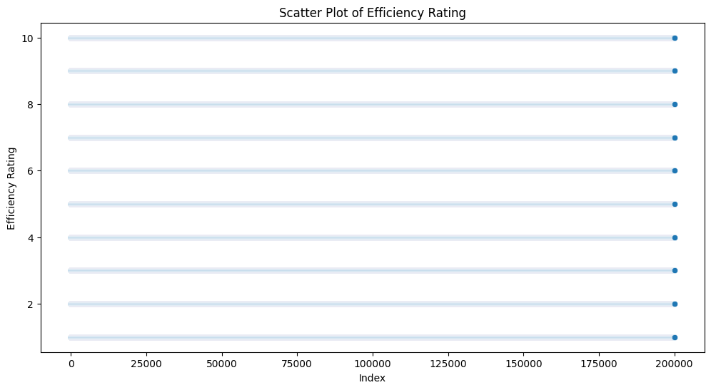

```python
import matplotlib.pyplot as plt
import seaborn as sns

column_name = 'Efficiency Rating'

# Plot the data points
plt.figure(figsize=(12, 6))
sns.scatterplot(data=df_containers, x=df_containers.index, y=column_name)
plt.title(f'Scatter Plot of {column_name}')
plt.xlabel('Index')
plt.ylabel(column_name)
plt.show()
```

summary statistics (such as count, mean, standard deviation, min, max, and quartiles) for the numerical columns in both the df_kubernetes and df_containers datasets.

```python
# Summary statistics for numerical columns
print("Cost Efficient Kubernetes Strategy - Summary Stats")
print(df_kubernetes.describe())
print("\nEfficient Container Orchestration Strategy - Summary Stats")
print(df_containers.describe())
```

```
Cost Efficient Kubernetes Strategy - Summary Stats
       Cost Efficiency Score  Resource Utilization (GB)  Scalability Index  \
count          200000.000000              200000.000000      200000.000000
mean                5.480905                  50.077965          50.013123
std                 2.872697                  28.616503          28.903501
min                 1.000000                   1.000000           0.000162
25%                 3.000000                  25.000000          25.003955
50%                 5.000000                  50.000000          50.047445
75%                 8.000000                  75.000000          75.094776
max                10.000000                  99.000000          99.999446

       Reliability Rating  Performance Metrics
count        200000.00000        200000.000000
mean              3.00521           500.123375
std               1.41355           289.015712
min               1.00000             0.005648
25%               2.00000           250.154035
50%               3.00000           499.311447
75%               4.00000           750.074480
max               5.00000           999.999270

Efficient Container Orchestration Strategy - Summary Stats
       Efficiency Rating  Resource Usage (GB)  Scalability Index  \
count      200000.000000        200000.000000      200000.000000
mean            5.508215            50.008375          50.006753
std             2.873493            28.591476          28.896006
min             1.000000             1.000000           0.000281
25%             3.000000            25.000000          25.048101
50%             6.000000            50.000000          49.901965
75%             8.000000            75.000000          75.030448
max            10.000000            99.000000          99.999639

       Reliability Score  Performance Index
count      200000.000000      200000.000000
mean            3.006560         501.191196
std             1.413059         287.981581
min             1.000000           0.006299
25%             2.000000         252.513537
50%             3.000000         501.529099
75%             4.000000         750.544676
max             5.000000         999.999124
```

Plotting histograms with KDE to compare the distributions of feature pairs between the df_kubernetes and df_containers datasets.

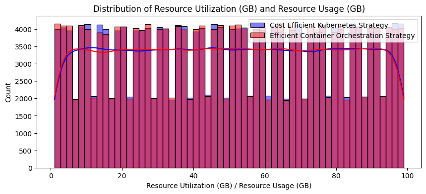

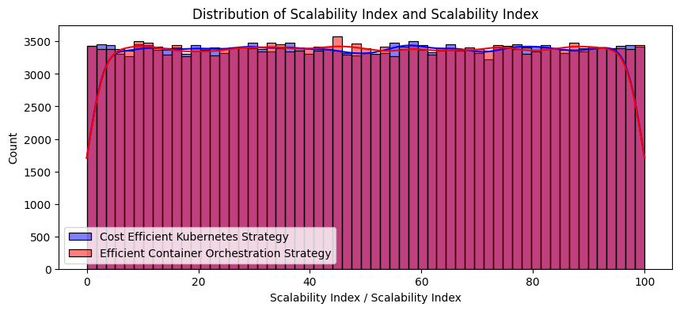

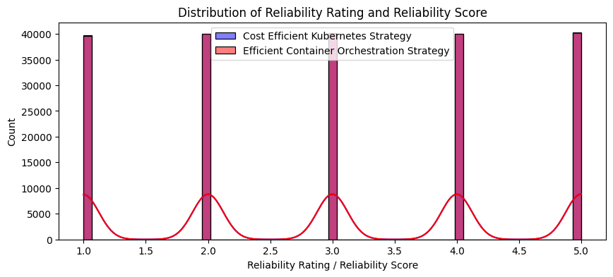

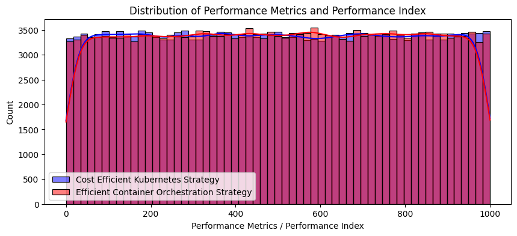

```python
import matplotlib.pyplot as plt
import seaborn as sns

# List of columns to compare
columns_to_compare = [
    ('Resource Utilization (GB)', 'Resource Usage (GB)'),
    ('Scalability Index', 'Scalability Index'),
    ('Reliability Rating', 'Reliability Score'),
    ('Performance Metrics', 'Performance Index')
]

# Plot histograms for each pair of columns
for col1, col2 in columns_to_compare:
    plt.figure(figsize=(10, 4))

    # Plot for the first dataset
    sns.histplot(df_kubernetes[col1], color="blue", kde=True, label='Cost Efficient Kubernetes Strategy')
    # Plot for the second dataset
    sns.histplot(df_containers[col2], color="red", kde=True, label='Efficient Container Orchestration Strategy')

    plt.title(f'Distribution of {col1} and {col2}')
    plt.xlabel(f'{col1} / {col2}')
    plt.legend()
    plt.show()
```

**Data Pre-Processing**

Renaming columns in the df_kubernetes dataset for consistency and displaying the first few rows after the changes.

```python
import pandas as pd


# Rename columns for consistency
df_kubernetes = df_kubernetes.rename(columns={
    "Organization Name": "Company Name",
    "Cost Efficiency Score": "Efficiency Rating",
    "Resource Utilization (GB)": "Resource Usage (GB)",
    "Reliability Rating": "Reliability Score",
    "Performance Metrics": "Performance Index",
    "Security Compliance":"Compliance Status",
    "Operational Flexibility": "Flexibility Level"
})
print(df_kubernetes.head())
```

```
               Company Name Deployment Date Cloud Provider Resource Type  \
0  General Electric Company      2021-12-06          Azure    Containers
1                Tesla Inc.      2021-06-26            GCP           VMs
2             Alphabet Inc.      2021-12-18            GCP    Containers
3                Adobe Inc.      2021-09-29            AWS           VMs
4    McDonald's Corporation      2021-01-29            AWS           VMs

   Efficiency Rating  Resource Usage (GB)  Scalability Index  \
0                  7                    7          87.515776
1                  2                   18          52.225125
2                  6                   89          89.427559
3                  2                   51          73.606632
4                  2                   31          46.930119

   Reliability Score Flexibility Level Compliance Status  Performance Index
0                  2              High     Non-compliant         272.035717
1                  2               Low         Compliant         505.860540
2                  4              High         Compliant         716.266607
3                  2               Low     Non-compliant         143.507699
4                  3               Low     Non-compliant         220.060235
```

Adding a "Source" column to both df_kubernetes and df_containers datasets, labeling them as "Kubernetes" and "Container" respectively, and displaying the first few rows of the updated df_kubernetes dataset.

```python
# Add a "Source" column to each dataset
df_kubernetes["Source"] = "Kubernetes"
df_containers["Source"] = "Container"
print(df_kubernetes.head())
```

```
               Company Name Deployment Date Cloud Provider Resource Type  \
0  General Electric Company      2021-12-06          Azure    Containers
1                Tesla Inc.      2021-06-26            GCP           VMs
2             Alphabet Inc.      2021-12-18            GCP    Containers
3                Adobe Inc.      2021-09-29            AWS           VMs
4    McDonald's Corporation      2021-01-29            AWS           VMs

   Efficiency Rating  Resource Usage (GB)  Scalability Index  \
0                  7                    7          87.515776
1                  2                   18          52.225125
2                  6                   89          89.427559
3                  2                   51          73.606632
4                  2                   31          46.930119

   Reliability Score Flexibility Level Compliance Status  Performance Index  \
0                  2              High     Non-compliant         272.035717
1                  2               Low         Compliant         505.860540
2                  4              High         Compliant         716.266607
3                  2               Low     Non-compliant         143.507699
4                  3               Low     Non-compliant         220.060235

       Source
0  Kubernetes
1  Kubernetes
2  Kubernetes
3  Kubernetes
4  Kubernetes
```

```python
# Display unique values for categorical columns
print("Cloud Providers in Kubernetes Data:", df_kubernetes["Cloud Provider"].unique())
print("Cloud Providers in Container Data:", df_containers["Cloud Provider"].unique())

print("Resource Types in Kubernetes Data:", df_kubernetes["Resource Type"].unique())
print("Resource Types in Container Data:", df_containers["Resource Type"].unique())

print("Flexibility Levels in Kubernetes Data:", df_kubernetes["Flexibility Level"].unique())
print("Flexibility Levels in Container Data:", df_containers["Flexibility Level"].unique())
```

```
Cloud Providers in Kubernetes Data: ['Azure' 'GCP' 'AWS']
Cloud Providers in Container Data: ['Azure' 'GCP' 'AWS']
Resource Types in Kubernetes Data: ['Containers' 'VMs']
Resource Types in Container Data: ['Containers' 'VMs']
Flexibility Levels in Kubernetes Data: ['High' 'Low' 'Medium']
Flexibility Levels in Container Data: ['Medium' 'High' 'Low']
```

Concatenating the df_kubernetes and df_containers datasets into a single dataset, df_combined, while resetting the index.Later plotting them

```python
# Concatenate the two datasets
df_combined = pd.concat([df_kubernetes, df_containers], ignore_index=True)
```

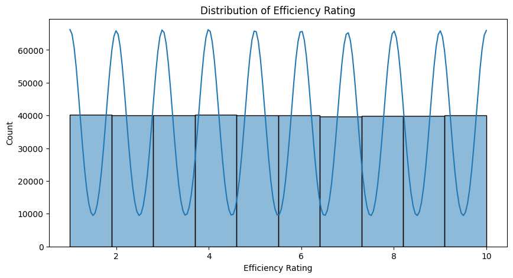

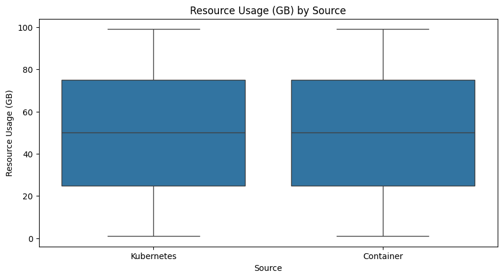

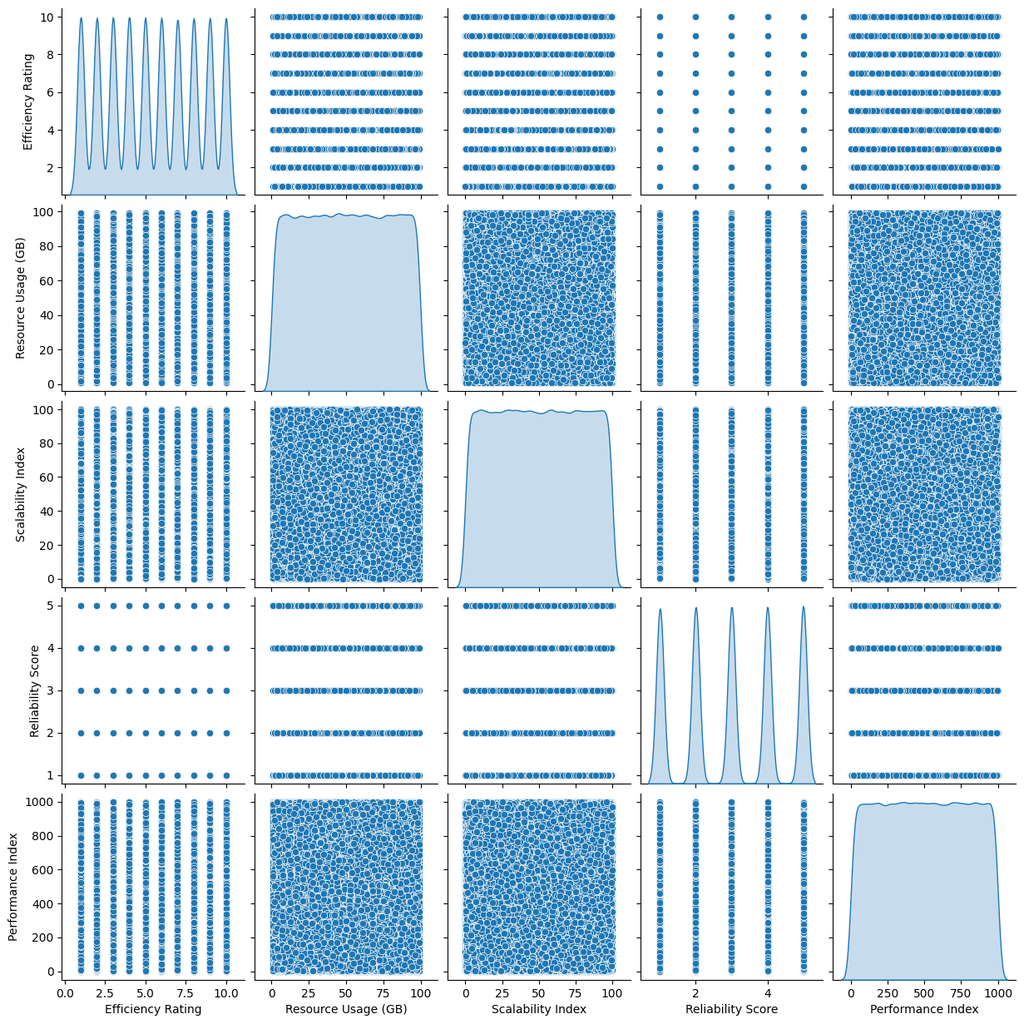

```python
import matplotlib.pyplot as plt
import seaborn as sns

# Histogram for Efficiency Rating
plt.figure(figsize=(10, 5))
sns.histplot(df_combined['Efficiency Rating'], bins=10, kde=True)
plt.title('Distribution of Efficiency Rating')
plt.show()

# Boxplot for Resource Usage (GB) grouped by Source
plt.figure(figsize=(10, 5))
sns.boxplot(data=df_combined, x="Source", y="Resource Usage (GB)")
plt.title('Resource Usage (GB) by Source')
plt.show()

# Pairplot for numerical columns
sns.pairplot(df_combined[['Efficiency Rating', 'Resource Usage (GB)', 'Scalability Index',
                          'Reliability Score', 'Performance Index']], diag_kind='kde')
plt.show()
```

Checking for missing values

```python
print("Missing values in the combined dataset:")
print(df_combined.isnull().sum())
print(df_combined.head())
print(df_combined.info())
```

```
Missing values in the combined dataset:
Company Name           0
Deployment Date        0
Cloud Provider         0
Resource Type          0
Efficiency Rating      0
Resource Usage (GB)    0
Scalability Index      0
Reliability Score      0
Flexibility Level      0
Compliance Status      0
Performance Index      0
Source                 0
dtype: int64
               Company Name Deployment Date Cloud Provider Resource Type  \
0  General Electric Company      2021-12-06          Azure    Containers
1                Tesla Inc.      2021-06-26            GCP           VMs
2             Alphabet Inc.      2021-12-18            GCP    Containers
3                Adobe Inc.      2021-09-29            AWS           VMs
4    McDonald's Corporation      2021-01-29            AWS           VMs

   Efficiency Rating  Resource Usage (GB)  Scalability Index  \
0                  7                    7          87.515776
1                  2                   18          52.225125
2                  6                   89          89.427559
3                  2                   51          73.606632
4                  2                   31          46.930119

   Reliability Score Flexibility Level Compliance Status  Performance Index  \
0                  2              High     Non-compliant         272.035717
1                  2               Low         Compliant         505.860540
2                  4              High         Compliant         716.266607
3                  2               Low     Non-compliant         143.507699
4                  3               Low     Non-compliant         220.060235

       Source
0  Kubernetes
1  Kubernetes
2  Kubernetes
3  Kubernetes
4  Kubernetes
<class 'pandas.core.frame.DataFrame'>
RangeIndex: 400000 entries, 0 to 399999
Data columns (total 12 columns):
 #   Column               Non-Null Count   Dtype
---  ------               --------------   -----
 0   Company Name         400000 non-null  object
 1   Deployment Date      400000 non-null  object
 2   Cloud Provider       400000 non-null  object
 3   Resource Type        400000 non-null  object
 4   Efficiency Rating    400000 non-null  int64
 5   Resource Usage (GB)  400000 non-null  int64
 6   Scalability Index    400000 non-null  float64
 7   Reliability Score    400000 non-null  int64
 8   Flexibility Level    400000 non-null  object
 9   Compliance Status    400000 non-null  object
 10  Performance Index    400000 non-null  float64
 11  Source               400000 non-null  object
dtypes: float64(2), int64(3), object(7)
memory usage: 36.6+ MB
None
```

**Feature Selection**

Selecting relevant features and the target variable from the df_combined dataset, and creating a new DataFrame, df_model, with the chosen columns for further analysis.

```python
# Select relevant features and target variable
features = [
    'Cloud Provider',
    'Resource Usage (GB)',
    'Scalability Index',
    'Reliability Score',
    'Flexibility Level',
    'Compliance Status',
    'Resource Type',
    'Performance Index'
]
target = 'Efficiency Rating'

# Create a new DataFrame with selected features and target
df_model = df_combined[features + [target]].copy()
```

```python
from scipy.stats import skew

# Calculate skewness of the target variable
target_skewness = skew(df_combined['Efficiency Rating'])
print(f"Skewness of target variable: {target_skewness}")
```

```
Skewness of target variable: 0.003544651636675388
```

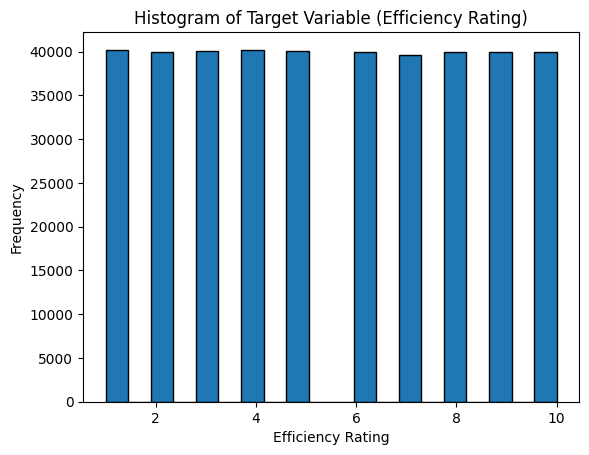

```python
import matplotlib.pyplot as plt

# Plot histogram for the target variable
plt.hist(df_combined['Efficiency Rating'], bins=20, edgecolor='k')
plt.title('Histogram of Target Variable (Efficiency Rating)')
plt.xlabel('Efficiency Rating')
plt.ylabel('Frequency')
plt.show()
```

[figure not shown]

```python
import matplotlib.pyplot as plt

# Plot histogram for the target variable
plt.hist(df_combined['Scalability Index'], bins=20, edgecolor='k')
plt.title('Histogram of Target Variable (Efficiency Rating)')
plt.xlabel('Scalability Index')
plt.ylabel('Frequency')
plt.show()
```

Reapplying one-hot encoding to the non-numeric columns in df_model and checking if there are any remaining non-numeric columns after encoding. The code then prints the non-numeric columns, if any.

```python
# Reapply one-hot encoding to the identified non-numeric columns
df_model = pd.get_dummies(df_model, columns=['Cloud Provider', 'Flexibility Level', 'Compliance Status', 'Resource Type'])

# Check if all columns are now numeric
non_numeric_columns = df_model.select_dtypes(exclude=["number"]).columns
print("Non-numeric columns after encoding:", non_numeric_columns)
```

```
Non-numeric columns after encoding: Index(['Cloud Provider_AWS', 'Cloud Provider_Azure', 'Cloud Provider_GCP',
       'Flexibility Level_High', 'Flexibility Level_Low',
       'Flexibility Level_Medium', 'Compliance Status_Compliant',
       'Compliance Status_Non-compliant', 'Resource Type_Containers',
       'Resource Type_VMs'],
      dtype='object')
```

Splitting 80% for training and 20% for testing

```python
from sklearn.model_selection import train_test_split

# Split the data into training and testing sets
X = df_model.drop(columns=[target])
y = df_model[target]
X_train, X_test, y_train, y_test = train_test_split(X, y, test_size=0.2, random_state=42)
```

**Model Selection**

```python
from sklearn.ensemble import RandomForestRegressor
from sklearn.metrics import mean_squared_error, r2_score

# Initialize and train the model
model = RandomForestRegressor(random_state=42)
model.fit(X_train, y_train)

# Make predictions
y_pred = model.predict(X_test)

# Evaluate the model
mse = mean_squared_error(y_test, y_pred)
r2 = r2_score(y_test, y_pred)

print(f"RandomForestRegressor- Mean Squared Error: {mse}")
print(f"RandomForestRegressor- R-squared: {r2}")
```

```
RandomForestRegressor- Mean Squared Error: 8.528464307499998
RandomForestRegressor- R-squared: -0.03800660888522578
```

```python
from sklearn.ensemble import GradientBoostingRegressor
gb_model = GradientBoostingRegressor(random_state=42)
gb_model.fit(X_train, y_train)
gb_y_pred = gb_model.predict(X_test)
gb_mse = mean_squared_error(y_test, gb_y_pred)
gb_r2 = r2_score(y_test, gb_y_pred)
print(f"Gradient Boosting - Mean Squared Error: {gb_mse}")
print(f"Gradient Boosting - R-squared: {gb_r2}")
```

```
Gradient Boosting - Mean Squared Error: 8.219083767457825
Gradient Boosting - R-squared: -0.0003516415141546769
```

```python
from joblib import dump  # Make sure to import dump

# Export the trained model to a .joblib file
dump(gb_model, 'gradient_boosting_model.joblib')
```

```
['gradient_boosting_model.joblib']
```

```python
from sklearn.linear_model import LinearRegression
# Linear Regression
lr_model = LinearRegression()
lr_model.fit(X_train, y_train)
lr_y_pred = lr_model.predict(X_test)
lr_mse = mean_squared_error(y_test, lr_y_pred)
lr_r2 = r2_score(y_test, lr_y_pred)
print(f"Linear Regression - Mean Squared Error: {lr_mse}")
print(f"Linear Regression - R-squared: {lr_r2}")
```

```
Linear Regression - Mean Squared Error: 8.216768279699044
Linear Regression - R-squared: -6.982153933310364e-05
```

```python
from sklearn.preprocessing import StandardScaler
# Scale the features
scaler = StandardScaler()
X_train_scaled = scaler.fit_transform(X_train)
X_test_scaled = scaler.transform(X_test)
```

```python
import tensorflow as tf
from tensorflow.keras.models import Sequential
from tensorflow.keras.layers import Dense, Input
```

```python
# Define the model with Input layer
model = Sequential()
model.add(Input(shape=(X_train_scaled.shape[1],)))  # Input layer with specified shape
model.add(Dense(64, activation='relu'))  # Hidden layer
model.add(Dense(64, activation='relu'))  # Hidden layer
model.add(Dense(1))  # Output layer
```

```python
model.compile(loss='mean_squared_error', optimizer='adam', metrics=['mean_squared_error'])
```

```python
history = model.fit(X_train_scaled, y_train, epochs=100, batch_size=32, validation_split=0.2)
```

[output not shown]

[output cut: 45 more lines]

[output not shown]

```python
loss, mse = model.evaluate(X_test_scaled, y_test)
print(f'Mean Squared Error on Test Set: {mse}')
```

```
2500/2500 ━━━━━━━━━━━━━━━━━━━━ 9s 4ms/step - loss: 8.2283 - mean_squared_error: 8.2283
Mean Squared Error on Test Set: 8.230108261108398
```

```python
predictions = model.predict(X_test_scaled)
```

```
2500/2500 ━━━━━━━━━━━━━━━━━━━━ 7s 3ms/step
```

```python
# Calculate R-squared
r2 = r2_score(y_test, predictions)
print(f"R-squared on Test Set: {r2:.4f}")
```

```
R-squared on Test Set: -0.0017
```

```python
print(df_model.head())
```

```
   Resource Usage (GB)  Scalability Index  Reliability Score  \
0                    7          87.515776                  2
1                   18          52.225125                  2
2                   89          89.427559                  4
3                   51          73.606632                  2
4                   31          46.930119                  3

   Performance Index  Efficiency Rating  Cloud Provider_AWS  \
0         272.035717                  7               False
1         505.860540                  2               False
2         716.266607                  6               False
3         143.507699                  2                True
4         220.060235                  2                True

   Cloud Provider_Azure  Cloud Provider_GCP  Flexibility Level_High  \
```

[output cut: 26 more lines]

Dropping Performance Index for Improvment

```python
df_model = df_model.drop(columns=['Performance Index'])
print(df_model.head())
```

```
   Resource Usage (GB)  Scalability Index  Reliability Score  \
0                    7          87.515776                  2
1                   18          52.225125                  2
2                   89          89.427559                  4
3                   51          73.606632                  2
4                   31          46.930119                  3

   Efficiency Rating  Cloud Provider_AWS  Cloud Provider_Azure  \
0                  7               False                  True
1                  2               False                 False
2                  6               False                 False
3                  2                True                 False
4                  2                True                 False

   Cloud Provider_GCP  Flexibility Level_High  Flexibility Level_Low  \
```

[output cut: 26 more lines]

```python
from sklearn.model_selection import train_test_split

# Split the data into training and testing sets
X = df_model.drop(columns=[target])
y = df_model[target]
X_train, X_test, y_train, y_test = train_test_split(X, y, test_size=0.2, random_state=42)
```

```python
from sklearn.ensemble import GradientBoostingRegressor
gb_model = GradientBoostingRegressor(random_state=42)
gb_model.fit(X_train, y_train)
gb_y_pred = gb_model.predict(X_test)
gb_mse = mean_squared_error(y_test, gb_y_pred)
gb_r2 = r2_score(y_test, gb_y_pred)
print(f"Gradient Boosting - Mean Squared Error: {gb_mse}")
print(f"Gradient Boosting - R-squared: {gb_r2}")
```

```
Gradient Boosting - Mean Squared Error: 8.22086771524115
Gradient Boosting - R-squared: -0.0005687673086978151
```